# Régression linéaire et logistique

Daniel Pont

03/07/2020

# Régression linéaire et logistique

## 1. Régression linéaire

### 1.1 Exemple

#### 1.1.1 Chargement des données et création d’un modèle

```r
# 2016 US Census PUMS dataset
# le but est de prédire le salaire (PINCP) à partir de pramaètres
# tels que l'age, le sex,...

psub <- readRDS("data/psub.RDS")
set.seed(3454351)
gp <- runif(nrow(psub))
dtrain <- subset(psub, gp >= 0.5)
dtest <- subset(psub, gp < 0.5)

model <- lm(log10(PINCP) ~ AGEP + SEX + COW + SCHL, data = dtrain)

dtest$predLogPINCP <- predict(model, newdata = dtest)
dtrain$predLogPINCP <- predict(model, newdata = dtrain)
```

#### 1.1.2 Représentation du log du revenu réel en fonction du log du revenu prédit

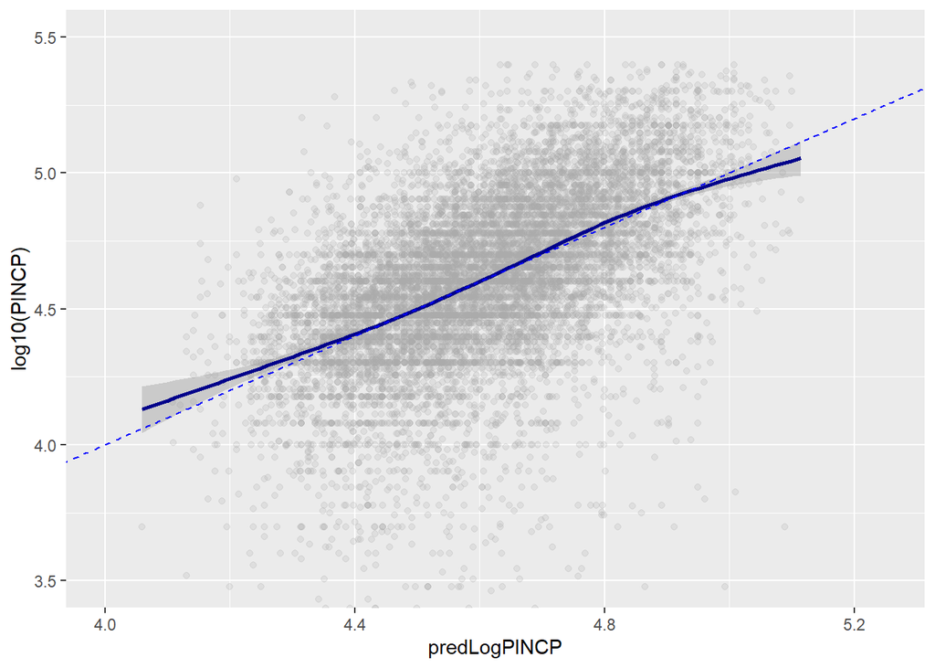

```r
library(ggplot2)
ggplot(data = dtest, aes(x = predLogPINCP, y = log10(PINCP))) +
    geom_point(alpha = 0.2, color = "darkgray") +
    geom_smooth(color = "darkblue") +
    geom_line(aes(x = log10(PINCP),
    y = log10(PINCP)),
    color = "blue", linetype = 2) +
    coord_cartesian(xlim = c(4, 5.25),
    ylim = c(3.5, 5.5))
```

#### 1.1.3 Représentation des erreurs résiduelles en fonction du log du revenu prédit

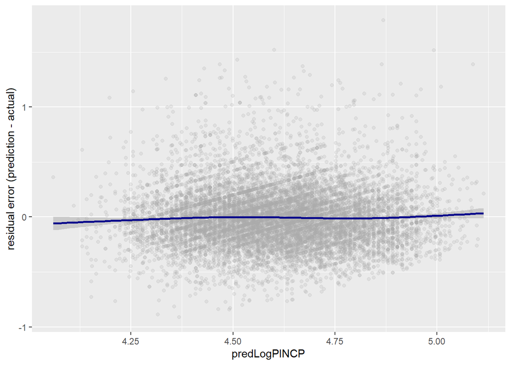

```r
ggplot(data = dtest, aes(x = predLogPINCP,
        y = predLogPINCP - log10(PINCP))) +
        geom_point(alpha = 0.2, color = "darkgray") +
        geom_smooth(color = "darkblue") +
        ylab("residual error (prediction - actual)")
```

#### 1.1.4 Coefficient de détermination (R^2)

```r
rsq <- function(y, f) { 1 - sum((y - f)^2)/sum((y - mean(y))^2) }

rsq(log10(dtrain$PINCP), dtrain$predLogPINCP)
```

```
## [1] 0.2976165
```

```r
rsq(log10(dtest$PINCP), dtest$predLogPINCP)
```

```
## [1] 0.2911965
```

#### 1.1.5 Erreur quadratique moyenne (RMSE)

```r
rmse <- function(y, f) { sqrt(mean( (y-f)^2 )) }

rmse(log10(dtrain$PINCP), dtrain$predLogPINCP)
```

```
## [1] 0.2685855
```

```r
rmse(log10(dtest$PINCP), dtest$predLogPINCP)
```

```
## [1] 0.2675129
```

#### 1.1.6 Résumé des erreurs résiduelles

```r
( resids_train <- summary(log10(dtrain$PINCP) - predict(model, newdata = dtrain)) )
```

```
##    Min. 1st Qu.  Median    Mean 3rd Qu.    Max.
## -1.5038 -0.1354  0.0187  0.0000  0.1710  0.9741
```

```r
( resids_test <- summary(log10(dtest$PINCP) - predict(model, newdata = dtest)) )
```

```
##      Min.   1st Qu.    Median      Mean   3rd Qu.      Max.
## -1.789150 -0.130733  0.027413  0.006359  0.175847  0.912646
```

## 2. Régression logistique

### 2.1 Exemple

#### 2.1.1 Chargement des données

```r
load("data/NatalRiskData.rData")

train <- sdata[sdata$ORIGRANDGROUP <= 5 , ]
test <- sdata[sdata$ORIGRANDGROUP > 5, ]
```

#### 2.1.2 Construction et du modèle de régression logisique

```r
complications <- c("ULD_MECO","ULD_PRECIP","ULD_BREECH")

riskfactors <- c("URF_DIAB", "URF_CHYPER", "URF_PHYPER","URF_ECLAM")

y <- "atRisk"
x <- c( "PWGT",
        "UPREVIS",
        "CIG_REC",
        "GESTREC3",
        "DPLURAL",
        complications,
        riskfactors)

library(wrapr)

fmla <- mk_formula(y, x)

print(fmla)
```

```
## atRisk ~ PWGT + UPREVIS + CIG_REC + GESTREC3 + DPLURAL + ULD_MECO +
##     ULD_PRECIP + ULD_BREECH + URF_DIAB + URF_CHYPER + URF_PHYPER +
##     URF_ECLAM
## <environment: base>
```

```r
model <- glm(fmla, data = train, family = binomial(link = "logit"))
```

#### 2.1.3 Application du modèle

```r
train$pred <- predict(model, newdata=train, type = "response")
test$pred <- predict(model, newdata=test, type="response")
```

#### 2.1.4 Calcul des probabilités marginales

```r
sum(train$atRisk == TRUE)
```

```
## [1] 273
```

```r
sum(train$pred)
```

```
## [1] 273
```

```r
premature <- subset(train, GESTREC3 == "< 37 weeks")

sum(premature$atRisk == TRUE)
```

```
## [1] 112
```

```r
sum(premature$pred)
```

```
## [1] 112
```

#### 2.1.5 Représentation des scores de prédiction groupés par classe résultat

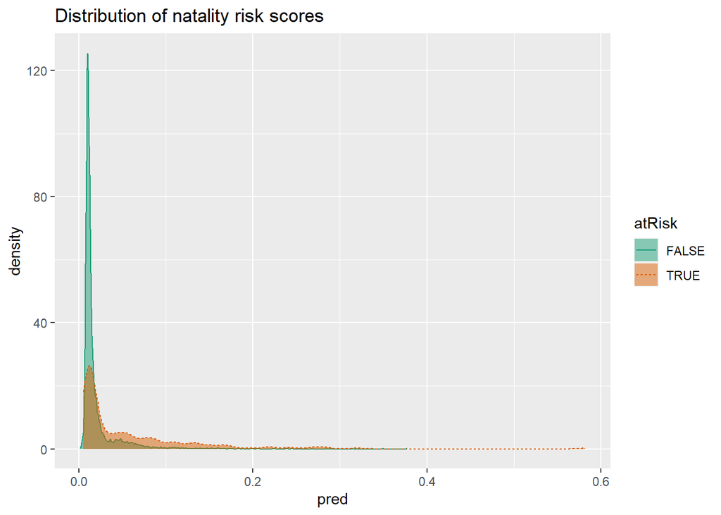

```r
library(WVPlots)

DoubleDensityPlot(train, "pred", "atRisk",
            title = "Distribution of natality risk scores")
```

#### 2.1.6 Exploration des compromis du modèle

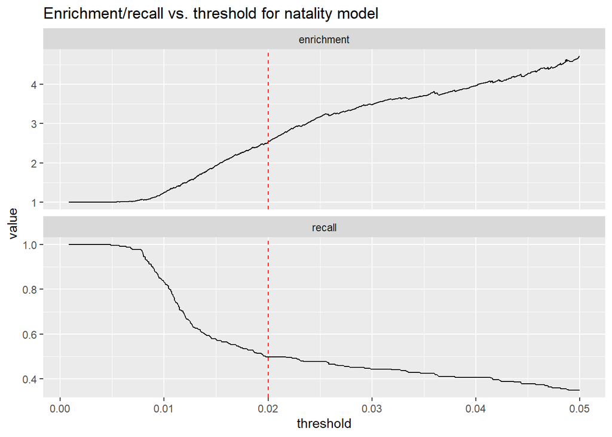

```r
library("WVPlots")
library("ggplot2")

plt <- PRTPlot(train, "pred", "atRisk", TRUE,
plotvars = c("enrichment", "recall"),
thresholdrange = c(0,0.05),
title = "Enrichment/recall vs. threshold for natality model")
plt + geom_vline(xintercept = 0.02, color="red", linetype = 2)
```

#### 2.1.7 Coefficient de régression

```r
coefficients(model)
```

```
##              (Intercept)                     PWGT                  UPREVIS
##              -4.41218940               0.00376166              -0.06328943
##              CIG_RECTRUE       GESTREC3< 37 weeks DPLURALtriplet or higher
##               0.31316930               1.54518311               1.39419294
##              DPLURALtwin             ULD_MECOTRUE           ULD_PRECIPTRUE
##               0.31231871               0.81842627               0.19172008
##           ULD_BREECHTRUE             URF_DIABTRUE           URF_CHYPERTRUE
##               0.74923672              -0.34646672               0.56002503
##           URF_PHYPERTRUE            URF_ECLAMTRUE
##               0.16159872               0.49806435
```

#### 2.1.8 Résumé du modèle

```r
summary(model)
```

```
##
## Call:
## glm(formula = fmla, family = binomial(link = "logit"), data = train)
##
## Deviance Residuals:
##     Min       1Q   Median       3Q      Max
## -0.9732  -0.1818  -0.1511  -0.1358   3.2641
##
## Coefficients:
##                           Estimate Std. Error z value Pr(>|z|)
## (Intercept)              -4.412189   0.289352 -15.249  < 2e-16 ***
## PWGT                      0.003762   0.001487   2.530 0.011417 *
## UPREVIS                  -0.063289   0.015252  -4.150 3.33e-05 ***
## CIG_RECTRUE               0.313169   0.187230   1.673 0.094398 .
## GESTREC3< 37 weeks        1.545183   0.140795  10.975  < 2e-16 ***
## DPLURALtriplet or higher  1.394193   0.498866   2.795 0.005194 **
## DPLURALtwin               0.312319   0.241088   1.295 0.195163
## ULD_MECOTRUE              0.818426   0.235798   3.471 0.000519 ***
## ULD_PRECIPTRUE            0.191720   0.357680   0.536 0.591951
## ULD_BREECHTRUE            0.749237   0.178129   4.206 2.60e-05 ***
## URF_DIABTRUE             -0.346467   0.287514  -1.205 0.228187
## URF_CHYPERTRUE            0.560025   0.389678   1.437 0.150676
## URF_PHYPERTRUE            0.161599   0.250003   0.646 0.518029
## URF_ECLAMTRUE             0.498064   0.776948   0.641 0.521489
## ---
## Signif. codes:  0 '***' 0.001 '**' 0.01 '*' 0.05 '.' 0.1 ' ' 1
##
## (Dispersion parameter for binomial family taken to be 1)
##
##     Null deviance: 2698.7  on 14211  degrees of freedom
## Residual deviance: 2463.0  on 14198  degrees of freedom
## AIC: 2491
##
## Number of Fisher Scoring iterations: 7
```

#### 2.1.9 Calcul de la déviance

```r
loglikelihood <- function(y, py) {
    sum(y * log(py) + (1-y)*log(1 - py))
}

(pnull <- mean(as.numeric(train$atRisk)) )
```

```
## [1] 0.01920912
```

```r
(null.dev <- -2 *loglikelihood(as.numeric(train$atRisk), pnull) )
```

```
## [1] 2698.716
```

```r
model$null.deviance
```

```
## [1] 2698.716
```

```r
pred <- predict(model, newdata = train, type = "response")

(resid.dev <- -2 * loglikelihood(as.numeric(train$atRisk), pred) )
```

```
## [1] 2462.992
```

```r
model$deviance
```

```
## [1] 2462.992
```

```r
testy <- as.numeric(test$atRisk)

testpred <- predict(model, newdata = test, type = "response")

( pnull.test <- mean(testy) )
```

```
## [1] 0.0172713
```

```r
( null.dev.test <- -2 * loglikelihood(testy, pnull.test) )
```

```
## [1] 2110.91
```

```r
( resid.dev.test <- -2 * loglikelihood(testy, testpred) )
```

```
## [1] 1947.094
```

#### 2.1.10 Calcul du pseudo R^2

```r
pr2 <- 1 - (resid.dev / null.dev)
print(pr2)
```

```
## [1] 0.08734674
```

```r
pr2.test <- 1 - (resid.dev.test / null.dev.test)
print(pr2.test)
```

```
## [1] 0.07760427
```

```r
# df = degree of freedom

(df.null <- dim(train)[[1]] - 1 )
```

```
## [1] 14211
```

```r
( df.model <- dim(train)[[1]] - length(model$coefficients) )
```

```
## [1] 14198
```

```r
( delDev <- null.dev - resid.dev )
```

```
## [1] 235.724
```

```r
( deldf <- df.null - df.model )
```

```
## [1] 13
```

```r
( deldf <- df.null - df.model )
```

```
## [1] 13
```

#### 2.1.12 Calcul de l’AIC (Akaike information criterion)

```r
aic <- 2 * (length(model$coefficients) -loglikelihood(as.numeric(train$atRisk), pred))
aic
```

```
## [1] 2490.992
```

## 3. Régularisation

### 3.1 Exemple de séparation quasi-complète

On parle de séparation complète lorsqu’une combinaison linéaire de prédicteurs génère une prévision parfaite de la variable de réponse. La séparation quasi-complète est semblable à la séparation complète. Les prédicteurs génèrent une prévision parfaite de la variable de réponse pour la plupart des valeurs des prédicteurs, mais pas pour toutes.

#### 3.1.1 Préparation des données

Le datataset “cars” présente le classement de differentes voitures en fonction de paramètres tels que la sécurité, le prix, etc.

```r
cars <- read.table(
    'data/car.data.csv',
    sep = ',',
    header = TRUE,
    stringsAsFactor = TRUE
)

vars <- setdiff(colnames(cars), "rating")
cars$fail <- cars$rating == "unacc"
outcome <- "fail"

set.seed(24351)
gp <- runif(nrow(cars))

library(zeallot)

c(cars_test, cars_train) %<-% split(cars, gp < 0.7)

nrow(cars_test)
```

```
## [1] 499
```

```r
nrow(cars_train)
```

```
## [1] 1229
```

#### 3.1.2 Construction d’un modèle de régression logistique

```r
library(wrapr)
(fmla <- mk_formula(outcome, vars) )
```

```
## fail ~ buying + maint + doors + persons + lug_boot + safety
## <environment: base>
```

```r
model_glm <- glm(fmla,
                data = cars_train,
                family = binomial)
```

```
## Warning: glm.fit: fitted probabilities numerically 0 or 1 occurred
```

Le warning “glm.fit: fitted probabilities numerically 0 or 1 occurred” indique que le problème est quasi-séparable.

On peut confirmer ce problème en résumant le résumé du modèle

#### 3.1.3 Résumé du modèle

```r
summary(model_glm)
```

```
##
## Call:
## glm(formula = fmla, family = binomial, data = cars_train)
##
## Deviance Residuals:
##      Min        1Q    Median        3Q       Max
## -2.35684  -0.02593   0.00000   0.00001   3.11185
##
## Coefficients:
##                Estimate Std. Error z value Pr(>|z|)
## (Intercept)     28.0132  1506.0310   0.019 0.985160
## buyinglow       -4.6616     0.6520  -7.150 8.67e-13 ***
## buyingmed       -3.8689     0.5945  -6.508 7.63e-11 ***
## buyingvhigh      1.9139     0.4318   4.433 9.30e-06 ***
## maintlow        -3.2542     0.5423  -6.001 1.96e-09 ***
## maintmed        -3.2458     0.5503  -5.899 3.66e-09 ***
## maintvhigh       2.8556     0.4865   5.869 4.38e-09 ***
## doors3          -1.4281     0.4638  -3.079 0.002077 **
## doors4          -2.3733     0.4973  -4.773 1.82e-06 ***
## doors5more      -2.2652     0.5090  -4.450 8.58e-06 ***
## persons4       -29.8240  1506.0310  -0.020 0.984201
## personsmore    -29.4551  1506.0310  -0.020 0.984396
## lug_bootmed      1.5608     0.4529   3.446 0.000568 ***
## lug_bootsmall    4.5238     0.5721   7.908 2.62e-15 ***
## safetylow       29.9415  1569.3789   0.019 0.984778
## safetymed        2.7884     0.4134   6.745 1.53e-11 ***
## ---
## Signif. codes:  0 '***' 0.001 '**' 0.01 '*' 0.05 '.' 0.1 ' ' 1
##
## (Dispersion parameter for binomial family taken to be 1)
##
##     Null deviance: 1484.7  on 1228  degrees of freedom
## Residual deviance:  245.5  on 1213  degrees of freedom
## AIC: 277.5
##
## Number of Fisher Scoring iterations: 21
```

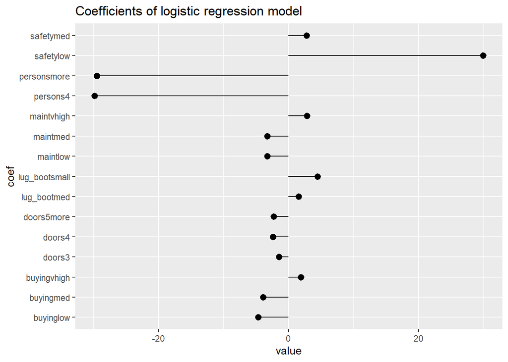

```r
coefs <- coef(model_glm)[-1]
coef_frame <- data.frame(coef = names(coefs),
                  value = coefs)

library(ggplot2)
ggplot(coef_frame, aes(x = coef, y = value)) +
    geom_pointrange(aes(ymin = 0, ymax = value)) +
    ggtitle("Coefficients of logistic regression model") +
    coord_flip()
```

Les variables safetylow, persons4 , et personsmore ont une magnitude et une erreur standard importante.

#### 3.1.4 Performance du modèle

```r
cars_test$pred_glm <- predict(model_glm,newdata=cars_test,type = "response")

# sigr permet de calculer la deviance
library(sigr)

confmat <- function(dframe, predvar) {
    cmat <- table(truth = ifelse(dframe$fail, "unacceptable", "passed"),
    prediction = ifelse(dframe[[predvar]] > 0.5, "unacceptable", "passed"))
    accuracy <- sum(diag(cmat)) / sum(cmat)
    deviance <- calcDeviance(dframe[[predvar]], dframe$fail)
    list(confusion_matrix = cmat, accuracy = accuracy, deviance = deviance)
}

confmat(cars_test, "pred_glm")
```

```
## $confusion_matrix
##               prediction
## truth          passed unacceptable
##   passed          150            9
##   unacceptable     17          323
##
## $accuracy
## [1] 0.9478958
##
## $deviance
## [1] 97.14902
```

### 3.2 Types de régularisation

- Ridge (L2)
- Lasso (L1)
- Elastic Net

### 3.3 Régression régularisée avec glmnet

#### 3.3.1 Régression Ridge

```r
library(glmnet)
library(glmnetUtils)

(model_ridge <- cv.glmnet(fmla,
                      cars_train,
                      alpha = 0,
                      family = "binomial"))
```

```
## Call:
## cv.glmnet.formula(formula = fmla, data = cars_train, alpha = 0,
##     family = "binomial")
##
## Model fitting options:
##     Sparse model matrix: FALSE
##     Use model.frame: FALSE
##     Number of crossvalidation folds: 10
##     Alpha: 0
##     Deviance-minimizing lambda: 0.02070555  (+1 SE): 0.02272432
```

Coefficients du modèle :

```r
(coefs <- coef(model_ridge))
```

```
## 22 x 1 sparse Matrix of class "dgCMatrix"
##                         1
## (Intercept)    2.07036883
## buyinghigh     0.36087302
## buyinglow     -0.79254703
## buyingmed     -0.65142106
## buyingvhigh    1.09666271
## mainthigh      0.19759816
## maintlow      -0.74515941
## maintmed      -0.62369242
## maintvhigh     1.17974674
## doors2         0.39060689
## doors3         0.01157841
## doors4        -0.22310921
## doors5more    -0.18460775
## persons2       2.70267398
## persons4      -1.40286590
## personsmore   -1.30448195
## lug_bootbig   -0.54140935
## lug_bootmed   -0.19315198
## lug_bootsmall  0.70910326
## safetyhigh    -1.75604427
## safetylow      2.63014095
## safetymed     -0.86745196
```

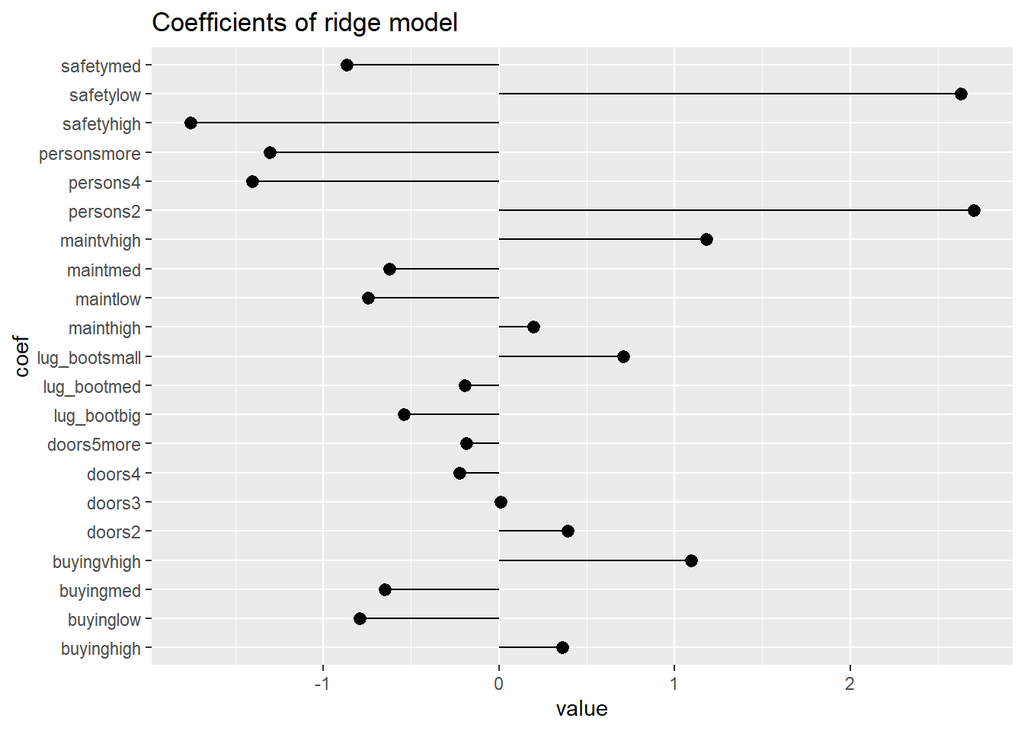

```r
coef_frame <- data.frame(coef = rownames(coefs)[-1], value = coefs[-1,1])

ggplot(coef_frame, aes(x = coef, y = value)) +
        geom_pointrange(aes(ymin = 0, ymax = value)) +
        ggtitle("Coefficients of ridge model") +
        coord_flip()
```

Performance du modèle :

```r
prediction <- predict(model_ridge,
                newdata = cars_test,
                type = "response")

cars_test$pred_ridge <- as.numeric(prediction)

confmat(cars_test, "pred_ridge")
```

```
## $confusion_matrix
##               prediction
## truth          passed unacceptable
##   passed          148           11
##   unacceptable     16          324
##
## $accuracy
## [1] 0.9458918
##
## $deviance
## [1] 187.2484
```

#### 3.3.2 Régression Lasso

```r
library(glmnet)
library(glmnetUtils)

(model_ridge <- cv.glmnet(fmla,
                      cars_train,
                      alpha = 1,
                      family = "binomial"))
```

```
## Call:
## cv.glmnet.formula(formula = fmla, data = cars_train, alpha = 1,
##     family = "binomial")
##
## Model fitting options:
##     Sparse model matrix: FALSE
##     Use model.frame: FALSE
##     Number of crossvalidation folds: 10
##     Alpha: 1
##     Deviance-minimizing lambda: 0.0003374489  (+1 SE): 0.00314706
```

Coefficients du modèle :

```r
(coefs <- coef(model_ridge))
```

```
## 22 x 1 sparse Matrix of class "dgCMatrix"
##                          1
## (Intercept)   -3.490572558
## buyinghigh     2.130073331
## buyinglow     -0.484316414
## buyingmed     -0.063502978
## buyingvhigh    3.462620670
## mainthigh      1.789611042
## maintlow      -0.100431986
## maintmed      -0.003575177
## maintvhigh     3.669603868
## doors2         0.895514080
## doors3         .
## doors4        -0.343442597
## doors5more    -0.271136865
## persons2       9.024723222
## persons4      -0.170117581
## personsmore    .
## lug_bootbig   -0.807448994
## lug_bootmed    .
## lug_bootsmall  1.831519730
## safetyhigh    -1.708007731
## safetylow      7.714889107
## safetymed      .
```

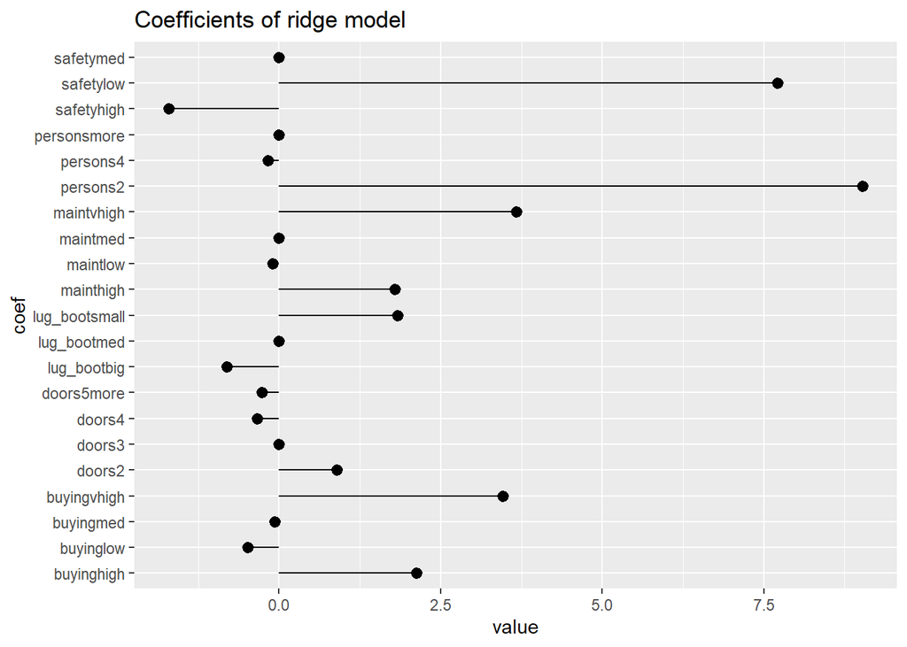

```r
coef_frame <- data.frame(coef = rownames(coefs)[-1], value = coefs[-1,1])

ggplot(coef_frame, aes(x = coef, y = value)) +
        geom_pointrange(aes(ymin = 0, ymax = value)) +
        ggtitle("Coefficients of ridge model") +
        coord_flip()
```

Performance du modèle :

```r
prediction <- predict(model_ridge,
                newdata = cars_test,
                type = "response")

cars_test$pred_ridge <- as.numeric(prediction)

confmat(cars_test, "pred_ridge")
```

```
## $confusion_matrix
##               prediction
## truth          passed unacceptable
##   passed          151            8
##   unacceptable     17          323
##
## $accuracy
## [1] 0.9498998
##
## $deviance
## [1] 114.4721
```

La précision du modèle lasso sur les données de test est similaire à celle du modèle ridge, mais la déviance est beaucoup plus faible, ce qui indique de meilleures performances.

#### 3.3.3 Régression Elastic Net

Le processus d’extraction du meilleur modèle est un peu complexe. Contrairement à *cv.glmnet*, *cva. glmnet* ne renvoie ni alpha.min ni alpha.1se. Au lieu de cela, le champ elastic_ net $ alpha renvoie tous les alphas que la fonction a essayés (11 d’entre eux, par défaut), et elastic_net $ modlist renvoie tous les objets de modèle glmnet :: cv.glmnet correspondants

```r
(elastic_net <- cva.glmnet(fmla,
                    cars_train,
                    family = "binomial"))
```

```
## Call:
## cva.glmnet.formula(formula = fmla, data = cars_train, family = "binomial")
##
## Model fitting options:
##     Sparse model matrix: FALSE
##     Use model.frame: FALSE
##     Alpha values: 0 0.001 0.008 0.027 0.064 0.125 0.216 0.343 0.512 0.729 1
##     Number of crossvalidation folds for lambda: 10
```

Détermination de la valeur alpha optimale (produisant l’erreur minimale) :

```r
# returne l'erreur moyenne de la validation croisée
get_cvm <- function(model) {
    index <- match(model$lambda.1se, model$lambda)
    model$cvm[index]
}

# récupère les valeurs apha testées par l'algorithme
enet_performance <- data.frame(alpha = elastic_net$alpha)

# récupère la liste des modèles
models <- elastic_net$modlist

# évalue l'erreur pour chaque modèle
enet_performance$cvm <- vapply(models, get_cvm, numeric(1))

# détermine l'erreur minimale
minix <- which.min(enet_performance$cvm)

# retourne la valeur alpha correspondante
(best_alpha <- elastic_net$alpha[minix])
```

```
## [1] 0.216
```

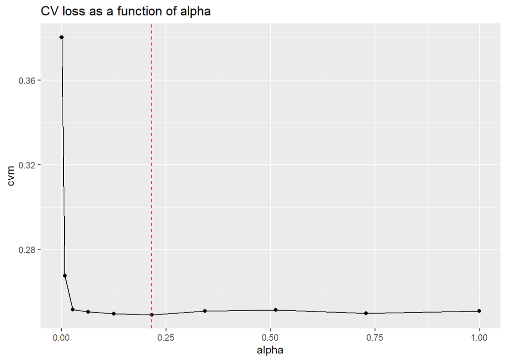

```r
ggplot(enet_performance, aes(x = alpha, y = cvm)) +
        geom_point() +
        geom_line() +
        geom_vline(xintercept = best_alpha, color = "red", linetype = 2) +
        ggtitle("CV loss as a function of alpha")
```

Construction du modèle finale (avec la valeur alpha optimale) et évaluation des performances :

```r
(model_enet <- cv.glmnet(fmla,
                  cars_train,
                  alpha = best_alpha,
                  family = "binomial"))
```

```
## Call:
## cv.glmnet.formula(formula = fmla, data = cars_train, alpha = best_alpha,
##     family = "binomial")
##
## Model fitting options:
##     Sparse model matrix: FALSE
##     Use model.frame: FALSE
##     Number of crossvalidation folds: 10
##     Alpha: 0.216
##     Deviance-minimizing lambda: 0.000183849  (+1 SE): 0.002487565
```

```r
prediction <- predict(model_enet,
                  newdata = cars_test,
                  type = "response")

cars_test$pred_enet <- as.numeric(prediction)

confmat(cars_test, "pred_enet")
```

```
## $confusion_matrix
##               prediction
## truth          passed unacceptable
##   passed          149           10
##   unacceptable     17          323
##
## $accuracy
## [1] 0.9458918
##
## $deviance
## [1] 117.6531
```